# 基于学习型社区模式的在线课程学习行为投入、效果评价及优化路径研究

总结报告

胡华平

周丹

2019-07-04

Abstract

本项目主要分析了学生课程形式选择、学习投入与学习效果的关系等议题，通过收集了四个年级（2013-2016级）共19452名学生在11个连续学期（2013秋学期-2018春学期）上的通识课程学习相关数据，进行了相关实证分析。本研究实证分析部分重点比较了学生在传统课程和在线课程上的学习行为和学习效果差异。相关实证分析发现：（1）为了完成通识课程模块学分，大部分学生在传统通识课程和在线通识课程之间做出了理性选择和平衡。大部分学生的通识课学分获得任务主要在前两年就会完成，学生在各个观察年的累计获得通识课程总学分基本服从正态分布。学生都会大二学年及以前选择并获得相应的在线课程学分，后续阶段基本就不再通过在线课程平台获得通识课程学分。（2）学生不会因为“新奇”心理而参加在线课程平台（无论是智慧树平台还是尔雅平台），更多只是为了完成通识课学分要求，因而学生的学习行为表现出典型的“理性人”特点。即便是同时拥有两个在线课程平台的选择自由，学生的选课决策和学习行为更多地是受到学分政策、平台依赖性等因素的决定。（3）影响学生选择在线或传统课程方式及学习效果的因素有很多，通过在线课程学习形式选择的倾向得分分析，发现高考分数与一本录取线分差越大、入学年龄越大、理科生、政治面貌为党员、来自农村地区、女生，越**不倾向**于选择在线课程；此外，学生更倾向于认为在线课程和传统课程学习形式在学习决策中具有较强的替代性关系。（4）对于课程学习效果的影响分析中，研究发现是否选择在线课程对课程成绩有显著正向影响。如果某个学生选择在线课程，则会比其选择传统课程高1.5205分。高考分数与录取线的分差对课程学习成绩有显著正向影响，如果一个学生高考分数与录取线（本省一本）的分差35分，那么这一分差水平将会为其带来课程成绩0.7406分的提高。（5）倾向得分分析方法的处置效应结论认为，男生的在线课成绩会潜在低于其传统课程成绩；高考分数与录取线分差小的学生、来自城镇的学生、非东部生源学生，这三类群体在线课程成绩都会潜在高于其传统课程成绩。如果学生能够自由选择在线课程，那么在线课程学习能够提高其课程成绩（ATT为正数）；但是正因为学生有了这种自由选择，却带来了全体学生平均课程成绩的降低（ATE为负数）。基于相关研究和实证结论，本项目进一步构建了在线课程学习效果评价指标体系，指出了学习型社区发展理念的重要实践价值，最后提出了若干政策建议。

# 1 引言

随着移动终端、物联网、云计算、大数据和学习分析等技术的发展 教育中的信息化生态已发生显著变化。 新技术的涌现以及它们对网络信息本质与数量的影响，正以前所未有的方式塑造着教育、学习情境的结构、 学习的本质、教师、学习者的角色等。同时，教育大数据的扩充和信息资源的激增，使学习演变为以信息资源和人际网络为基础的高度协作的社会建构活动。这种变化推动了学习环境各要素之间结构的变化，促进了教育理念的发展，促使着学习变得更加社会性、关联性、分布性、可视性、碎片化和个性化，使得非正式学习、微学习、适应性学习等逐渐流行起来。

伴随着在线课程的迅猛发展，大多数高校已经开始试点在全校范围认定在线课程学分。其中，对于通识类在线课程模块的开设和学分认定，大部分高校率先做出实质性的试点、推广和大规模应用。这主要得益于教育主管部门、高校、市场各方的政策激励和推动，以及通识类课程天然具有受众广、普适性等内在优势。根据师资、经费情况的不同，这些在线通识课程的开设主要通过高校自建或者第三方采购两种方式引入教学使用，而且在线通识课程往往是与传统通识课程并行开课。

把在线课程学习与学分挂钩，学生将面临新的决策条件和学习环境。一方面课程供给形式的自由度增大，学生自主学习的决策性更强，选课和学习热情会更高。另一方面，在线课程大多采用单一机器评价，学生学习过程难以监管，在上课、测试、考核过程中容易出现虚假操作、抄袭、舞弊等现象，课程结业成绩测定容易，但学习效果评估较难。此外，各类在线平台上课程水平参差不齐，还存在学科间课程标准不统一、学习辟垒差异较大等问题(张秀芹 and others 2017)，再加上高校相关配套政策不连续和操作程序尚未完善，容易引发学生的选课困惑和投机行为。

因此，传统课程和在线课程学习条件和学习行为存在较大差异情形下，学生的课程学习效果（如课程考试成绩、课程通过率等）是否可能也会有明显的不同？进一步地，假定学生可以自由选择课程形式，并且都可以获得同等地位的学分认定，课程形式（在线课程或传统课程）选择本身对两类课程的学习效果会带来多大的影响？不考虑课程学习行为（如注册时滞、登陆次数、访问资源次数、视频观看密度和时长、论坛互动数、提交作业数等）时，该如何识别学生背景性因素（包括高考分数、入学年龄、生源地、文理科类别、民族、性别等）对课程形式选择和学习效果产生的额外影响？基于以上考虑，本文将利用学生平台数据库记录数据，分析学生选择两类课程形式的倾向得分，并对学生群体样本进行匹配，从学生背景性因素视角综合对比在线课程选择的分化与学习效果差异。

# 2 重要概念与相关理论

## 2.1 学习投入和学习型社区

传统教学情境下，学习投入是指学习者在学习过程中投入的时间和精力(Kuh 2003)。而在线学习情境下的学习投入是学习者在线学习活动表现的状态，包括认知投入、情感投入和行为投入三方面。有研究者认为，在线学习投入是学习者参与在线交互活动的反映。Petty and Farinde (2013)、Davis (1996) 认为师生交互、生生合作、主动学习、及时反馈、时间管理、尊重个体差异、多样化学生方式同样可以用于考量在线学习投入。在线学习的新特点赋予了学习投入更宽泛的内涵，在线学习体验和交互行为成为概念解释发展的两个主要方面。学习者对学习过程的干燥、调控和情感支撑方面可以一定程度上反映学习者的努力程度，知识迁移、参与满足感和自我价值感也是在线学习投入的认知表现(Kim and Malhotra 2005; Lee 2015)。

社区一词拉丁语原意是伙伴关系，在社会学学科领域的解释是任何基于协作关系的有机组织形式，表示人与人之间的紧密关系、共同精神意识以及对社区共同的归属感和认同感。社区是一个区域性的概念（比如我们居住社区）它应是有边界的，学习社区是围绕学习目标建立的一个共同体，那么这个学习社区是否有边界？边界在哪？Kester et al. (2007) 认为，成功的社区具有清晰的边界，有一系列公共资源的使用制度和维护制度的奖惩机制，有对外捍卫集体财富的行为交互。共同的边界、规则、对可能发生的事情的监督和惩罚机制是社区的典型特征。

Barab (2003) 认为一种为个体提供共享和发展重叠的知识库、信仰体系、价值观、历史,以及关注共同实践和事业体验的持续的社会网络。Brown and Campione (1994) 认为学校可以被看成实践社区，其中的实践就是学校学习。传统的社区一般是从地理区域的角度去界定，从社会学社会网络的角度对社区的界定突破的空间位置的限定，从人与人之间的关系角度来界定无疑是社区研究的一项突破。 学习共同体（学习社区）可以定义为由学习者及其助学者（包括教师、助教等）共同构成的团体, 他们彼此之间经常在学习过程中进行沟通、交流，分享各种学习资源,共同完成一定的学习任务，从而在成员之间形成了相互影响，相互促进的的人际关系。本文认为学习社区是基于学习的组织形式，由教学者、学习者、助学者等共同构成的有机体，成员在教与学过程中形成了协作关系，形成了共同的学习目标和对学习社区的认同感。

## 2.2 学习投入的影响因素和决定机制

在行为科学视角下，学习行为可被理解为个体在环境的作用下有目的的活动，是个体和环境交互作用的产物和表现。关于在线课程学习行为的影响因素，目前文献主要从内部影响因素和外部影响因素两个方面进行分析。个体元认知和外部环境是学习行为投入的重要因素，也是投入决定机制的基本出发点(孔丽丽 et al. 2017)。

### 2.2.1 内部影响因素

内部影响因素主要包括个体特征、学习兴趣、学习动机、学习体验、学习自信心、学习认同等。

首先，学习个体存在异质性，将会决定学习行为的基本起点，个体特征主要表现为年龄、性别、家庭特征等。Robinson and Hullinger (2008) 调查发现，在线课程学习者的年龄对其学习投入有显著影响。不同年龄段的人对网络课程学习的投入重点和方向具有差异，在线学习也表现出不同特点：如25岁以下的学习者学习投入主要集中在资源收索和访问上，25岁以上则主要把精力放在如何达到预期目标而为此付出努力。25-34岁关注协助能力、批判思维和理性分析能力的学习，而45-54岁在线课程学习更加积极开展同伴互助。学习者阅读能力、书面沟通能力师影响在线课程学习的重要影响因素。 Amador and Mederer (2013) 和 Peck and others (2012) 的研究发现，学习者良好的博客写作技能可以帮助其提升学习参与度。

其次，认知论者主要从学习者自身的学习感知即“元认知”探讨在线课程学习投入。有学者从学习者自身的学习行为即“元认知投入”探讨学习投入。元认知投入主要包括认知知识、认知监控和认知管理(Akyol and Garrison 2011)，它是一种监控、协调学习过程的行为投入，学习者在线学习过程中自我导向、自我约束和自我激励的程度也依赖于元认知投入，元认知投入是学习者情感控制，意志策略层面上的在线学习投入也被认为是“学习存在”(Shea and Bidjerano 2012)。这种“学习存在”不仅包括在线学习者的认知存在，而且包括社会存在，表现在学习者在线学习会受到其所在学习社群影响并反过来表现在学习者个体身上(Garrison and Arbaugh 2007)。研究认为学习者的学习动机、自我效能感(易玉何 et al. 2018)、心流体验(王卫, 史锐涵, and 李晓娜 2017)、自信心(Milligan, Littlejohn, and Margaryan 2013)、在线学业情绪(高洁 and others 2016)、学习兴趣(谭光兴, 徐峰, and 屈文建 2012)等对在线学习投入影响显著。“元认知”不仅包括在线学习者对自身情感、意志控制的认知，而且包括社会因素的影响，也就是说学习者在线学习会受到其所在学习社群影响并反过来表现在学习者个体身上。

再次，研究表明自我效能感对在线学习投入影响显著。当在线学习者自我效能感高时，在线投入水平会显著提高(张琪 2015)。另外有研究表明在线学习的情绪是影响自我效能感的因素之一。高洁 and others (2016) 从社会认知的视角，对386名在线学习的大学生进行调查发现，在线学习者积极学业情绪、消极学业情绪、学习效能感与在线学习投入两两之间显著相关，在线学业情绪是影响在线学习投入的重要心理因素。感知有趣性、感知易用性、感知期望会同时影响在线用户的持续使用意图(刘人境, 张谦, and 闵文文 2013)。对在线培训服务的信任感也直接影响学习者的学习行为意向，兴趣性对学生接受在线教育的行为具有显著影响，甚至超过了感知易用的影响(陈渝 and 尹辉 2013)。Gefen的研究发现，网络学习经验增加，经验形成的习惯对学习者的感知有用性和感知易用性有影响，也显著影响他们的持续使用意愿(Gefen 2003)。Milligan, Littlejohn, and Margaryan (2013) 通过网络问卷调查发现学习者的动机、在线学习体验和自信心是在线学习参与的重要影响因素。

最后，一些研究还表明社交化互动可以形成个体认同感，也是正向推动在线学习投入重要的变量(杨根福 2016)。王钱永 and 毛海波 (2016) 通过构建分析学生MOOC学习行为的UTAUT模型发现学习者的在线学习行为容易受到周围环境和其他同学的影响，当周围环境和其他同学对MOOC学习产生正面作用时，那么在一定程度上会提高学生的学习意图。

### 2.2.2 外部影响因素

外部影响因素来自于教学实施过程中的各种支持条件，主要包括硬件、师资、内容、技术、政策、文化等。为学习者提供能激发其参与交互活动的在线学习环境是激发学习者学习投入的有效途径(Dixson 2010)。

营造良好的在线学习环境需要强大的技术支持。技术因素又受学习资源来源的影响。在大数据时代，在线资源来源较资源内容对系统有用性的影响强度更大(季志 2013)。异步通讯技术、社交网络技术的发展为在线教育提供了技术支持，在线课程中web2.0技术的应用成为影响学习者体验的重要因素。在线学习是一种需要高效率技术支持的学习方式(Harrell and Bower 2011)。学习者会因受网络中各种活动的干扰而降低对课程内容与学习任务的关注，容易出现辍学现象。技术功能纷繁也容易让学习者面临“技术搜寻”的困难，影响学生学习积极性(Henrie, Halverson, and Graham 2015)。

教师角色及行为对可以显著影响学习者的学习投入。在线学习中，“对话式教学”形成的问答互动、论坛言论情景等会正向影响学生学习投入(Reeve and Tseng 2011)。Leite, Svinicki, and Shi (2010) 研究教师发帖数、发帖质量对学生参与在线学习投入进行研究发现，教师发帖数量对学习者的行为投入有显著影响，教师参与与学生智力投入程度正相关。在线课程中采用基于问题教学模式更能激发学生高质量讨论和深度学习(Amador and Mederer 2013)。鼓励性的反馈更能促进在线学习者的认知投入，良好的教学任务设计是促进学习投入的关键(McNaught, Lam, and Cheng 2012)。反过来，在线学习中教师与学生交互功能的不足将对教学效果有负面影响。

通过分析学习者在线课程学习的登录、浏览和形成性考试数据，发现网络资源和学习支持服务是影响学生在线学习投入的两个重要外部因素。营造良好的在线学习环境需要强大的技术支持。技术因素又受学习资源来源的影响。在大数据时代，在线资源来源较资源内容对系统有用性的影响强度更大(季志 2013)。在互联网高度发达与移动互联网日趋完善的今天，与其他信息系统推广普及一样，技术先进与资源的可获得性与否并非关键，在线课程能否被用户认知、接受和持续使用是一个重要且值得关注的问题。

## 2.3 持续学习投入的作用机制

Fillion et al. (2007) 认为习惯是持续意图与持续行为之间关系的负向调节变量，习惯变量越强，持续使用意向对持续使用行为的预测就越弱。另一方面信息系统（IS）持续使用理论并未对用户的绩效做进一步的分析，该理论只假定了用户的持续使用意愿会有高的使用绩效，那么用户的以往使用绩效会影响其持续使用行为吗？ 对在线课程的个体认知和外部因素是影响学生初始使用最为关键的因素。而信息技术初始接受的影响因素并非完全等同于持续使用的行为的影响因素，因为用户对信息系统的感知和评价会随着时间而改变。目前对于在线学习的持续使用行为主要通过观测学习者的行为意愿来推断。具体来说就是从教师或学生的视角对信息系统（IS）或MOOC用户持续使用意愿的一般性影响因素进行分析，进而总结出具有普遍性的结论，研究发现感知有用性、期望确认、满意度是影响IS持续使用意愿的关键因素(Bhattacherjee 2001; Bhattacherjee, Perols, and Sanford 2008)。为学习者提供能激发其参与交互活动的在线学习环境是激发学习者学习投入的有效途径。

## 2.4 学习投入与学习效果的关系及相关理论假设

已有研究提出了很多关于测度学习投入和学习效果的工具、方法和手段。其中学习效果的测度主要包括显示性的学习成绩，以及内隐性的学习满意度两个方面。

### 2.4.1 绩效投入与学习效果

绩效投入是学习者参与同课程学习评价相关的规定任务(Appleton, Christenson, and Furlong 2008)，具体包括登录视频学习、阅读资料和提交作业、参加考试等。它是学生遵循和响应课程规定和教师要求的行为，是学习者在线学习活动的行为表现(Fredricks, Blumenfeld, and Paris 2004)。相关研究表明学习行为与课程持续使用意向之间的关联。主观的感知有用性和期望确认是影响学习者的持续使用意向的关键变量(杨根福 2016; 张哲 et al. 2016; 易玉何 et al. 2018)。而绩效投入实际上是对课程学习期望的确认过程，它也是学生在线学习的感知体验，对在线学习持续行为产生正向影响(方旭 and others 2015)。类似的研究也表明，如果在线学习的感知体验是消极的，则学生学习动机不足(Maltby and Whittle 2000)，学习满意度低，会导致较高的退学率。因此本文提出：

- 假设1：学生前期的在线课程学习绩效投入越多，学生连续选择在线课程的可能性越大。

学习投入理论构建了网络学习行为与学习效果之间的解释框架，该理论认为学习投入能够预测学习成绩(Schaufeli et al. 2002)。学习成绩用于表征客观的学习效果，学习者对学习效果的主观感知则是通过满意度和课程持续使用意向来表征的。换而言之，前期的学习效果会作用于学习者的主管感知进而影响其持续使用行为。因此本文提出

- 假设2：学生前期的在线课程学习成绩越好，学生连续选择在线课程的可能性越大。

Gefen (2003) 在研究模型中引入使用经验所积累的习惯变量对信息系统持续使用行为影响的发现，习惯变量不但对用户的感知有用性和感知易用性有影响，对其持续使用意向也有显著影响。Kim and Malhotra (2005) 的研究认为用户过去的使用行为会显著影响未来的使用行为，进而形成一种习惯性的使用行为。也就是说习惯会对持续使用行为产生一种惯性影响，因此笔者认为学生以往在线课程选择行为对后期选择行为的影响，以往的课程选择情况则可以考虑从以往在线课程选择课程频次（门次数）和广度（门类数）两个维度提出以下假设：

- 假设3：以往在线课程选择的频次越大，学生连续选择在线课程的可能性越大。
- 假设4：以往在线课程选择的广度越大，学生连续选择在线课程的可能性越大。

### 2.4.2 社会性学习行为与学习效果

社会性学习行为是指学习者在网络中维系与他人的社会性关系的行为(Hrastinski 2009)，关于社会性学习行为的类型学界并未形成统一的共识，但至少包含交流讨论、协作学习（协作学习行为则反映学习者与学习共同体之间的交互）等行为。本文的社会性学习行为具体包括在线交互活动和线下朋辈间交互活动。

在线交互活动是学生在线课程学习过程中的交互行为，通过课程中的讨论、交流、论坛留言来表征社会性交互频率和深度等，它涵盖了学习者与内容、教师、其他学生者之间的交互活动。已有的诸多研究表明，论坛在学习者的坚持方面起到了至关重要的作用。纽约大学的研究人员发现，论坛对于在线学习者的坚持性具有积极影响(Adamopoulos 2013)。那些MOOC学习中获得证书的学习者论坛发帖数要明显高于未获得证书学习者，几乎所有的“课程完成者”都具有较高的论坛参与率。很多国内的研究也同样表面，社会性学习行为中的在线讨论行为会对课程持续使用意向产生显著的影响(马志强 et al. 2017)。由此本文提出：

- 假设5：在线交互活动越多（强）学生在线课程持续选择行为可能性越大。

线下朋辈间交互包含了学习伙伴影响力，有权威和影响力的伙伴可以启动群体学习过程，虽然大部分的学生在线课程选择与学习都是个体独立行为，但 洪岩, 唐卉, and 梁林梅 (2013) 的研究表明，那些参加线下协作者的成绩要高于独立学习者，线下相互激励，分享各自学习经历并一同解决问题或提出对策，能够有效地激励学习者坚持完成在线课程的学习。伙伴激励和帮助会对学习者产生积极的促进效果。若是个体认为其社交关系网络中很大比例人都在使用网络，那么他就有更加强烈的学习组织中其他成员的社会规范，产生更强的持续使用意愿。另一方面线下朋辈间的交互还包括群体中个体成员之间联系的频率和强度，还有个体成员间相互信任以及对新事物的接受程度(Newig, Günther, and Pahl-Wostl 2010)。由此，本文认为同学间在线课程的动态选择会影响学生的选择行为，并提出：

- 假设6：联系越紧密的同学在线课程门次选择越多，则学生连续选择在线课程的可能性越大。
- 假设7：联系越紧密的同学在线课程选择门类数越广，则学生连续选择在线课程的可能性越大。

### 2.4.3 教育政策支持与学习效果

学习者进行在线学习需要有丰富的数字化资源和学习支持系统，才能更大的选择自主权，灵活调整和控制自己的学习活动。优质的在线学习资源是在线学习的客观动力。研究表明，学生获取教育信息资源的数量和质量决定了学习效果(熊才平, 何向阳, and 吴瑞华 2012)。如果学习支持系统的针对性和时效性不强、缺乏良好的教育环境的支持，则会有大量的学习者对在线学习产生观望和逃避心态(曹良亮 2014)。与完全在线修读学位的MOOC不同的是，在传统的专业学位人才培养计划中引入在线课程资源是在线课程学习的政策支持，政策作为一种约束和促进某种行为的行动框架，在保障在线学习参与及在线学习运行上具有决定性的作用(吴南中 2016)。它直接决定了在线课程资源的丰富性与可获得性。因此本文提出：

- 假设8：在培养计划中，在线课程允许选修的学分数越大，学生连续选择在线课程的可能性越大。
- 假设9：在培养计划中，在线课程可选择门数越多，学生连续选择在线课程的可能性越大。

# 3 在线课程学习基本情况分析

## 3.1 通识课程模块与在线课程学习平台

通识课程模块是学生毕业总学分的重要构成部分，学生毕业往往需要满足本专业的通识课程学分要求。一般而言，不同专业的通识课程学分要求各不相同。

表3.1: 培养方案中对通识课学分的要求

| 学院 | 学科门类 | 专业名称 | 2008版学分要求 | 2014版学分要求 |
| --- | --- | --- | --- | --- |
| 园艺学院 | 农学 | 园艺 | 6 | 4 |
| 动物医学院 | 农学 | 动物医学 | 7 | 5 |
| 经济管理学院 | 经济学 | 国际经济与贸易 | 17.5 | 5 |
| 经济管理学院 | 经济学 | 保险学 | 17.5 | 5 |
| 人文学院 | 管理学 | 公共事业管理 | 8 | 4 |

说明： 此处只列出了两次培养方案通识课学分差大于2的部分专业。

为了完成通识课程模块学分，学生可以选修传统通识课程，也可以选修在线通识课程。在线通识课程通过两个网络平台承担运行：

- 尔雅通识课[在线教学平台](http://erya.mooc.chaoxing.com/index)（记为EY）。由超星集团打造的一个在线通识课程教育品牌（基本情况介绍可登陆平台首页查看，网址：http://erya.mooc.chaoxing.com/about）。
- 智慧树通识课[在线教学平台](https://www.zhihuishu.com/)（记为ZH）。该平台的运行网站为智慧树网，是上海卓越睿新数码科技有限公司的一个在线通识课程平台（基本情况介绍可登陆平台首页查看，网址：https://www.zhihuishu.com/aboutus.html）。

两个在线课程平台先后启用，具体是：

- 2013年秋学期，开始引入并启用尔雅通识课在线教学平台。2015年秋学期，尔雅平台进行了系统升级更新。由于特定原因，尔雅平台在2018年春学期没有上线运行，学生在该学期不能选课。
- 2016年秋学期，开始引入并启用智慧树通识课在线教学平台。

## 3.2 学生群组和分布情况

本研究主要收集了四个年级（2013-2016级）共19452名学生在**11个连续学期**（2013秋学期-2018春学期）上的通识课程学习相关数据。考虑到尔雅在线平台和智慧树在线平台的上线运行时间，以及学生学业完成情况，本研究将全体学生划分为两个群组，其中：

- 样本群组1为2013年和2014年入学的学生，共计9726人。他们是第一批接触在线课程学分认定的学生，主要通过尔雅在线课程平台学习课程并获得通识课学分。因为在统计期内，该群组的学生基本已经完成学业，因此在线学分数和传统学分数，通过4学年累加得到（学生已经完成4年学业）。
- 样本群组2为2015年和2016年入学的学生，共计9671人。因为智慧树在线课程平台同步上线运行，他们开始有更多的在线课程选择机会。同时，也因为2014年培养方案调整和在线课程学分认定管理办法不断修订，他们的在线课程选择决策会变得更加复杂和多样化。因为在统计时期内，该群组的学生已经完成2年学业，因此在线学分数和传统学分数，通过2学年累加得到（学生已经完成2年学业）。

两个学生群组的基本情况分别见表3.2和表3.3：

表3.2: 样本基本情况1

| 学生分组 | 连续变量 | 均值 | 标准差 | 偏度 | 峰度 | 有效样本数n | 有效百分比% |
| --- | --- | --- | --- | --- | --- | --- | --- |
| sample1 | 在线学分数 | 1.141 | 1.549 | 1.3464 | 1.1696 | 9726 | 100.00% |
| sample1 | 高考录取线分差 | 37.006 | 37.072 | -3.5884 | 16.5746 | 9664 | 99.36% |
| sample1 | 传统学分数 | 4.522 | 1.988 | 0.3237 | 2.1226 | 9726 | 100.00% |
| sample2 | 在线学分数 | 2.551 | 2.292 | 0.6319 | -0.4682 | 9671 | 100.00% |
| sample2 | 高考录取线分差 | 56.443 | 31.798 | -3.2506 | 16.9784 | 9368 | 96.87% |
| sample2 | 传统学分数 | 5.327 | 2.512 | 0.2498 | -0.1444 | 9671 | 100.00% |

<sup>a</sup> 样本1主要是入学年份为2013年和2014年的学生  
<sup>b</sup> 样本2主要是入学年份为2015年和2016年的学生

表3.3: 样本基本情况2

| 学生分组 | 离散变量 | 取值 | 有效样本数n | 有效百分比% |
| --- | --- | --- | --- | --- |
| sample1 | 性别 | 男 | 4909 | 50.473% |
| sample1 | 性别 | 女 | 4817 | 49.527% |
| sample1 | 生源地 | 东北 | 454 | 4.7% |
| sample1 | 生源地 | 东部 | 2014 | 20.7% |
| sample1 | 生源地 | 西部 | 5218 | 53.7% |
| sample1 | 生源地 | 中部 | 2040 | 21.0% |
| sample1 | 户籍类型 | 城镇 | 5296 | 54.45% |
| sample1 | 户籍类型 | 农村 | 4430 | 45.55% |
| sample2 | 性别 | 男 | 4995 | 51.65% |
| sample2 | 性别 | 女 | 4676 | 48.35% |
| sample2 | 生源地 | 东北 | 445 | 4.6% |
| sample2 | 生源地 | 东部 | 1947 | 20.1% |
| sample2 | 生源地 | 西部 | 5127 | 53.0% |
| sample2 | 生源地 | 中部 | 2152 | 22.3% |
| sample2 | 户籍类型 | 城镇 | 5571 | 57.6% |
| sample2 | 户籍类型 | 农村 | 4100 | 42.4% |

<sup>a</sup> sample1 主要是入学年份为2013年和2014年的学生  
<sup>b</sup> sample2 主要是入学年份为2015年和2016年的学生

## 3.3 学生通识课程学分获得情况分析

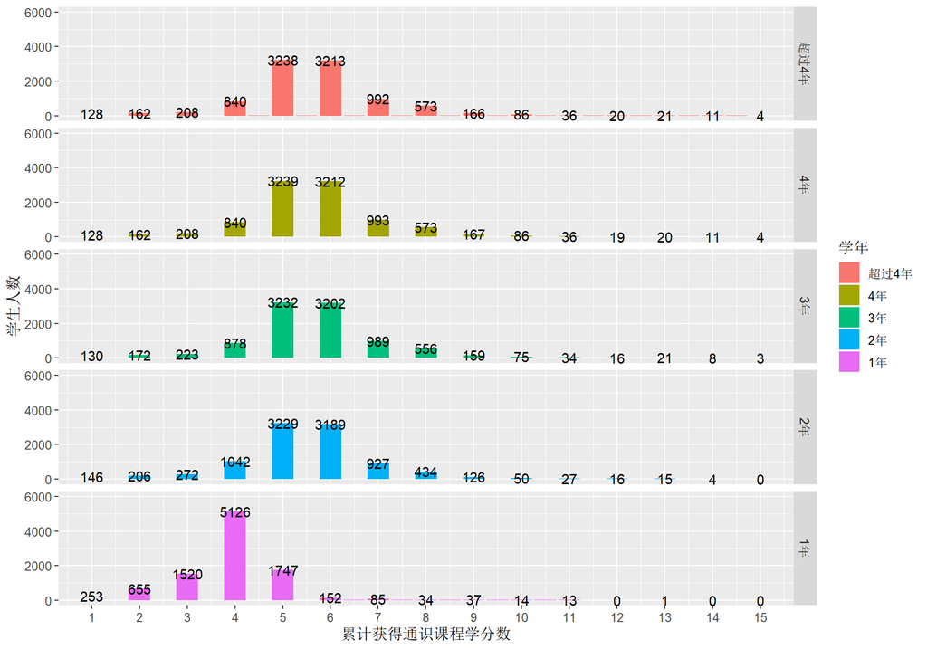

图3.1: 学生累计获得通识课程学分情况

第二，从学生获得**传统课程**学分来看（见图3.2），大一阶段的传统课程学分呈现正态分布，其他学习阶段（大二以后）学生获得的传统课学分呈偏态。简单地说，大部分学生在大一阶段获得基本的传统课学分，随后的学业阶段多是课程的兴趣选择和学分的择机补足。

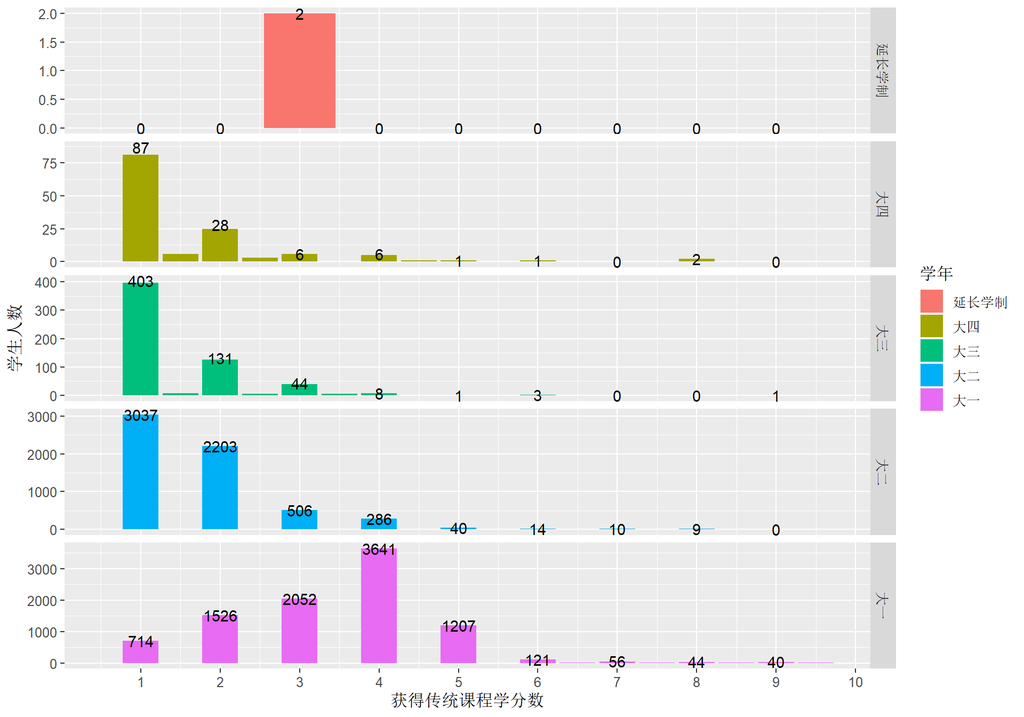

图3.2: 各学年分别获得传统课程学分情况

第三，从学生获得**在线课程**学分来看（见图3.3），无论在哪一个学业阶段，学生获得的在线课程学分的都表现出明显偏态。相比而言，在线课程并没有成为学生通识课选择的主要构成，学生大部分只会在各学业阶段选择1-2门在线课程。并且大部分学生都会在大一学年或大二学年选择并获得相应的在线课程学分，后续阶段基本就不再通过在线课程平台获得通识课程学分。

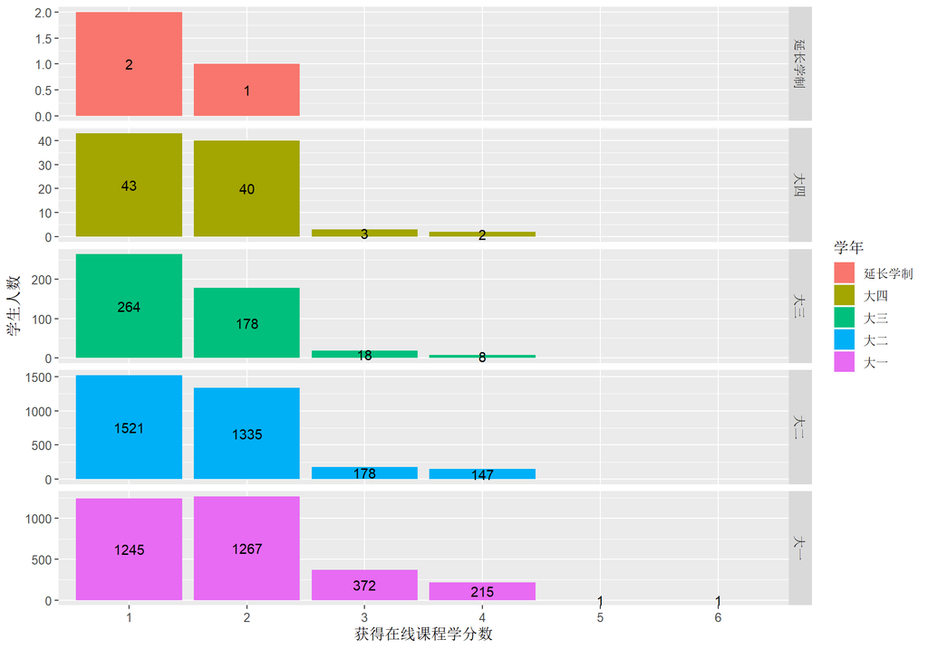

图3.3: 各年级在线课程选修学分分布情况

第四，学生逐年累加总在线学分的分布情况见图3.4。因为一名大学生选修在线课程，修课的决策一般分布在整个学业期（一般为4年）的各个学年。把各学年选修在线课程获得的学分逐年累加，会得到每个大学生的逐年累加总学分，且累加年数一般由1~4年。图3.4进一步印证了前述观点。

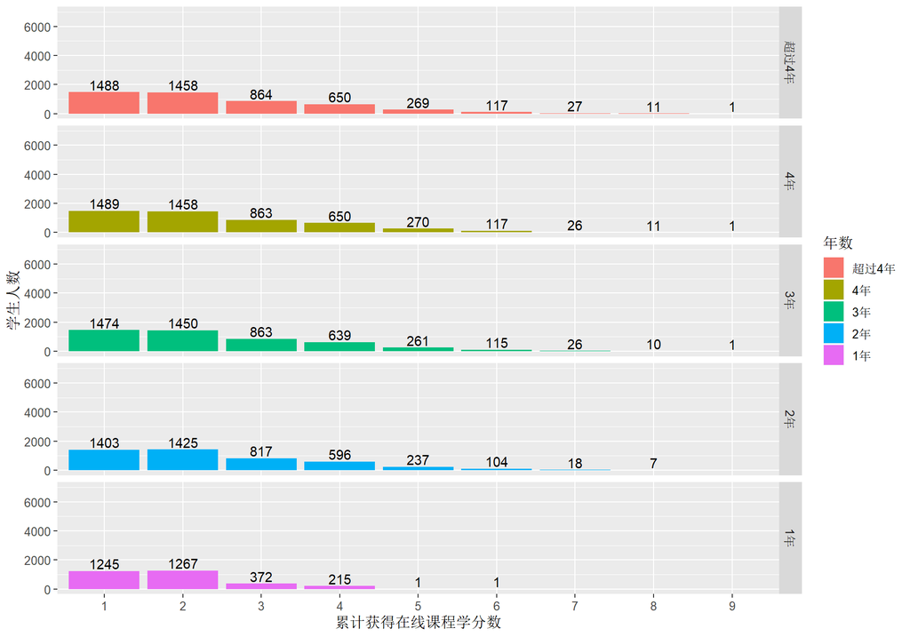

图3.4: 逐年累加的在线课程选修学分分布情况

## 3.4 尔雅平台与智慧树平台的选择情况

如前所述，因为尔雅平台和智慧树平台先后上线运行（前者2013年秋学期开始运行，后者2016秋学期开始运行），两个学生群组（2013年和2014年入学的群组1；2015年和2016年入学的群组2）在平台课程选择和留存上存在明显区别（见表3.4）。一方面，学生群组1（2013年和2014年入学）几乎很少使用智慧树平台，尽管这些学生在校时（已经大四或大三）智慧树平台已经启用。因此学生群组1大多完整地接触并体验了尔雅平台带来的在线课程选择，并且整体选课数量呈现“快速增加-逐渐减少”的衰减过程，学生不会因为“新奇”心理继续在智慧树平台课程选修课程，从而表现出典型的“理性人”行为特点。另一方面，学生群组2（2015年和2016年入学）几乎是同时拥有两个在线课程平台的选择自由，然而他们更偏好在尔雅平台上选修在线课程，智慧树平台作为后来者相对缺乏吸引力。

表3.4: 在线课程平台的选课人次统计

| 学生群组 | 在线课程平台 | 年份 | 学期 | 选课人数 |
| --- | --- | --- | --- | --- |
| 样本1 | 尔雅 | 2013 | 秋 | 973 |
| 样本1 | 尔雅 | 2014 | 春 | 1537 |
| 样本1 | 尔雅 | 2014 | 秋 | 2811 |
| 样本1 | 尔雅 | 2015 | 春 | 2213 |
| 样本1 | 尔雅 | 2015 | 秋 | 4582 |
| 样本1 | 尔雅 | 2016 | 春 | 904 |
| 样本1 | 尔雅 | 2016 | 秋 | 453 |
| 样本1 | 尔雅 | 2017 | 春 | 295 |
| 样本1 | 尔雅 | 2017 | 秋 | 115 |
| 样本2 | 尔雅 | 2015 | 秋 | 9320 |
| 样本2 | 尔雅 | 2016 | 春 | 2434 |
| 样本2 | 尔雅 | 2016 | 秋 | 7831 |
| 样本2 | 尔雅 | 2017 | 春 | 4221 |
| 样本2 | 尔雅 | 2017 | 秋 | 6285 |
| 样本2 | 智慧树 | 2016 | 秋 | 607 |
| 样本2 | 智慧树 | 2017 | 春 | 1307 |
| 样本2 | 智慧树 | 2017 | 秋 | 1673 |
| 样本2 | 智慧树 | 2018 | 春 | 4410 |

说明：  
考虑到在线平台启用时间的不同，智慧树平台只统计了样本2学生的选课记录  
<sup>a</sup> 样本1主要是入学年份为2013年和2014年的学生  
<sup>b</sup> 样本2主要是入学年份为2015年和2016年的学生

# 4 在线课程选择分化与学习效果的实证分析

## 4.1 文献评述

大量关于在线课程学习效果研究文献主要分析学生在线**学习行为**的影响效应，发现学习者的在线行为对学习效果有着重要影响，在线学习者与学习媒介、同伴和教师多层次广泛交互能提升学习效果(Kizilcec, Piech, and Schneider 2013; 宗阳 et al. 2016; 张晓蕾, 黄振中, and 李曼丽 2017; 王涛涛 and 毛晨蕾 2018)。然而，对于在线课程整体运行和政策环境还不够完善的发展阶段，这些研究一般很难反映学习者的真实学习投入水平，对学习过程中的行为轨迹、意愿与认知过程往往需要结合特定的调研问卷，变量测量准确性和模型预测准确性都会受到一定影响(江波 et al. 2018)。我国大多数本科院校目前正在使用本校或外校建设的在线课程。从使用情况来看，使用外校建设的在线课程数量（56.67%）远远高于本校建设的在线课程（33.33%）。在线课程在教学中的**应用表现**为多种形式，其中主要的应用方式是作为课堂教学的拓展学习资源，以及线上和线下结合的翻转课堂教学(张秀芹 and others 2017)。而且大部分在线课程考核常采用对期末考试、单元测验和参与讨论等学习环节作出加权评价得分，评价体系多元性不足，课程评价主体较为单一，同时机器评介也更容易忽略定性因素的考查(赵宏 et al. 2017)。

实际上影响学生选择在线或传统课程方式及学习效果的因素有很多。学习者选择参与在线课程学习，除了学习者对课程本身的态度、课程内容及质量高低外，学习者的背景特征（性别、地域、家庭条件）、学习动机（终身学习、娱乐或智力激发、职业发展等)、学习能力（自我决策、适应性调节、自主学习等）等均是影响课程方式选择和学习效果的重要方面(姜蔺, 韩锡斌, and 程建钢 2013; 梁林梅 2015)。学生对学习时间的安排能力、人际沟通方式的偏好性等可能会影响其课程决策和学习效果(Roblyer 1999; Hagel and Shaw 2010)。

在实证分析方法上，大量文献基于实验对照的方法分析在线课程和传统课程的学习效果差异，并强调对相关变量的控制和对照(Deschacht and Goeman 2015)。一种理想的对照情形是：一名教师同时开设有传统课程和在线课程，课程学时数近似，且学生能获得的学习资料或内容也差不多相同。Figlio, Rush, and Yin (2013) 对比分析了《微观经济学导论》的学习效果差异，他们发现传统授课形式的学习效果要好于在线授课形式。而 Joyce et al. (2015) 对比分析了传统授课和混合授课形式，发现两种形式下的学习效果仅有微小差异。 Alpert, Couch, and Harmon (2016) 对《经济学原理》不同授课形式做了随机分配，发现在线课程学生的学积分相对要低于传统课程，而且成绩不好的学生的在线课程表现会更糟糕。然而**实验对照分析方法**也具有一定的局限性。控制条件太多容易导致可供分析的学生样本较少，而且随机分配授课方式给特定学生群体还会涉及到社会和伦理问题，研究成本也相对较高。事实上，相比纯粹的**在线授课形式**，**混合在线授课形式**更加普遍。此外，如果在线课程仅仅只是体现在**呈现方式**上的不同，例如只是把传统课程上的课件、练习题、案例等在线化，那么这样的实验对照分析也将缺乏有效性。而且实验对照分析方法更多关注于回答“如果传统课程替换为在线课程，会有什么学习效果差异？”。但是它很难回答“如果学生具有更多在线课程选择，学习效果会有什么差异？”

完全随机的对照控制试验往往很难开展，而且一旦学生选择了在线课程学习，则无法观察到他们如若选择传统课程学习下的学习行为和学习效果。这使得直接采用传统普通多元回归分析方法，很难排除各种复杂混淆因素（如家庭收入、父母受教育程度、居住地、性别等）的对课程学习效果干扰，无法准确识别决定学习效果好坏的真正来源是课程选择本身还是各种复杂混淆因素。基于以上原因，一些学者采用**倾向得分分析（propensity score analysis, PSA）**和**内生转换模型**（endogenous switching model, ESM）来解决上述选择偏误问题，如经典的Heckman两阶段估计方法。Coates et al. (2004) 采用内生转换模型分析发现，在线课程学生分数要显著低于传统课程学生；但是选择在线课程的学生，会优于他们选择传统课程下的表现。通过采用工具变量来矫正选择偏误，Xu and Jaggars (2013) 实证结果发现选择在线课程学习的学生要相对传统课程学习要少获得1/3学分，并更有可能无法最终完成在线课学习，且这种差异在特定样本群组下会更明显，如更年轻的、学积分更低的学生群组。Krieg and Henson (2016) 检验了选择在线课程对于后续课程学分的影响，发现选择在线课程的学生在后续课程（可能是传统课也可能是在线课）学习中成绩相对会有降低。Huntington-Klein, Cowan, and Goldhaber (2017) 采用Heckman两阶段估计发现，一些学生只是因为空间便利性或时间灵活性，而把在线课程作为更乐于接受的新型学习机会（相比于传统课程），但这样往往很难使得这些学生保持连贯性的在线学习并通过课程考核，或者提供更多的在线课程，会使得在同领域课程学习的留存率更低，以及更低的课程通过率。

## 4.2 理论模型和分析方法

### 4.2.1 理论模型

高校在校生如果可以在两类课程形式上（在线课程O和传统课程F）自由选择，则可以构建如下的学习效用模型：

$$\begin {aligned}
u_{i}(c)=\alpha_{i 1} Y_{i c}+\alpha_{i 2} V_{i c}-\alpha_{i 3} P_{i c}
\end {aligned}$$

其中：$u_i(c)$表示学生$i$的效用；$Y_{ic}$表示选课的未来折现收益。它依赖于课程学习过程中的人力资本累积；$P_{ic}$表示选课的费用；$V_{ic}$表示选课的期望消费价值。包括课程学习本身获得的愉悦，以及非经济的或间接成本，比如精神压力。

相对传统课程（face-face），如果学生$i$更偏好在线课程（online），则有：

$$\begin {aligned}
u_{i}\left(c_{O}\right) & \geq u_{i}\left(c_{F}\right) \Rightarrow \\
\alpha_{i 1} Y_{i O}+\alpha_{i 2} V_{i O}-\alpha_{i 3} P_{i 0} & \geq \alpha_{i 1} Y_{i F}+\alpha_{i 2} V_{i F}-\alpha_{i 3} P_{i F}
&& \leftarrow P_{iO}=P_{iF} \\
\alpha_{i 1}\left(Y_{i O}-Y_{i F}\right)+\alpha_{i 2}\left(V_{i O}-V_{i F}\right) & \geq 0
\end {aligned}$$

假设在线课程和传统课程学习费用相等，也即$P_{iO}=P_{iF}$。显然，研究的主要关注点在于两个方面：（1）估计$(Y_{i O}-Y_{i F})$，也即在线课程选择会给全体学生带来多少收益？（2）折现收益差$(Y_{i O}-Y_{i F})$与选择行为$u_{i}\left(c_{O}\right) \geq u_{i}\left(c_{F}\right)$的关系。也即选择在线课程的学生，是不是也会在长期上获得最大的折现收益？

事实上，折现收益$(Y_{i O}-Y_{i F})$与期望消费价值$(V_{i O}-V_{i F})$一般呈现负相关关系。如果以上观点成立，这将意味着一个选择在线课程的学生，他的折现收益将会是相对较少的——在线课程太舒适了。这就产生了两个层次的有趣话题：（1）平均折现收益值（$E(Y_{iO} - Y_{iF}）$是多少？（2）如果选择在线课程，则需要补偿折现收益值，那它是如何不同的？

因此，进一步地可以分别估计不同学习形式的可能性：

$$\begin{aligned}
\operatorname{Pr} (Y_{i O} =1 ) &=\Phi\left(X_{i O} \beta_{O}\right) \\
\operatorname{Pr} (Y_{i F} =1 ) &=\Phi\left(X_{i F} \beta_{F}\right) \\
\operatorname{Pr} (\text {Online}_{i}=1 ) &=\Phi\left(X_{i} \beta_{S}+Z_{i} \gamma_{S}\right) \\
Online_i & = I(online_i^* \geq 0)
\end{aligned}$$

其中：$\Phi(\cdot)$为正态分布的累计概率函数cdf；$Y_{iO}$是研究者关心的结果变量（给定在线课程的处置条件），包括后续课程选择，或者是否获得结业学位；$Y_{iF}$是研究者关心的结果变量（给定传统课程的处置条件）：包括后续课程选择，或者是否获得结业学位。$X_{iO};X_{iF}$为变量向量，包括学生背景、早期成就变量、常数项、**随机效应变量**（与学校和课程相关）；$X_i$为变量向量，与$X_{iO};X_{iF}$一样，只是不考虑处置条件（是否为在线课程）；$Z_i$为被斥变量（工具变量）。它能影响选择在线课程还是传统课程，但是不影响结果变量；$Online_i^*$为学生个体在选择在线课程还是传统课程的潜在补偿值。

以上**自我选择问题**（self-selection issue）：Coates et al. (2004)的模型允许学生特征$X_i$对结果变量有不同的影响效应。因而不同课程形式的学校效果在不同群组中是可以不同的。以上模型的参数可以采用如下过程估计得到，它仅需要误差项满足**正态分布**条件。

- **第1阶段**：使用probit方法估计如下方程：

$$\begin{aligned}
\operatorname{Pr} (\text {Online}_{i}=1 ) &=\Phi\left(X_{i} \beta_{S}+Z_{i} \gamma_{S}\right)
\end{aligned}$$

- **第2阶段**：使用probit方法估计如下方程，并进行矫正：

$$\begin{aligned}
\operatorname{Pr} (Y_{i O} =1 ) &=\Phi\left(X_{i O} \beta_{O}\right) \\
\operatorname{Pr} (Y_{i F} =1 ) &=\Phi\left(X_{i F} \beta_{F}\right)
\end{aligned}$$

$$\begin {aligned}
\operatorname{Pr}\left(Y_{i O}=1\right)
&=\Phi\left(X_{i O} \beta_{O}+\frac{\phi\left(X_{i} \widehat{\beta_{S}}+Z_{i} \widehat{\gamma_{S}}\right)}{\Phi\left(X_{i} \widehat{\beta_{S}}+Z_{i} \widehat{\gamma_{S}}\right)} \delta_{O}\right) \\
\operatorname{Pr}\left(Y_{i F} =1\right)
&=\Phi\left(X_{i F} \beta_{F}+\frac{-\phi\left(X_{i} \widehat{\beta_{S}}+Z_{i} \widehat{\gamma_{S}}\right)}{1-\Phi\left(X_{i} \widehat{\beta_{S}}+Z_{i} \widehat{\gamma}_{S}\right)} \delta_{F}\right)
\end {aligned}$$

其中，$\phi(\cdot)$表示正态分布的概率密度函数pdf

### 4.2.2 倾向得分分析（PSA）和处置效应（TE）

**倾向得分分析（propensity score analysis, PSA）**方法最早由Rosenbaum(Rosenbaum and others 1987; Rosenbaum 2010) 提出，作为效果评估的常用工具，很早就被应用于在线学习效果研究领域(Guo and Fraser 2014; 顾振华 and others 2018)。研究者能把观察性样本数据（如学生在线课程选择和学习数据），处理成随机实验等效的样本数据（考虑到学生潜在可能选择传统课程并获得可能的课程成绩），从而减弱了样本自选择引起的模型内生性问题。

倾向得分分析（PSM）的**四个步骤**为：

- 采用logit模型计算倾向得分。以二值变量“是否选择在线课程”（treat）作为因变量建模。
- 倾向得分样本匹配。采用特定匹配算法（本文为full）匹配选择在线课程的学生样本和选择传统课程的学生样本，并对多个协变量（如高考分数、性别、生源地等）进行匹配平衡。
- 利用匹配样本进行多元回归分析。以课程成绩为因变量构建多元回归模型。
- 利用多元回归分析结果，计算两类处置效应：平均处置效应（ATE）和处置后的平均处置效应（ATT）。

处置效应（treatment effect）一般指测试组（选择在线课程）平均得分与控制组（选择传统课程）平均得分的净差值。主要分为平均处置效应(average treatment effect, ATE)和平均处置的处置效应(The average treatment effect on the treated, ATT)。如果采用随机化的处置分派机制（random treatment assignment mechanism,RTAM），那么以上两个效应应该是等价的，也即$ATE=ATT$。大量文献表明在实践应用研究中，二者往往是不相等的。

**平均处置效应**（ATE），有时候也称为平均因果效应(average causal effect, ACE)，是指处置组和控制组在结果变量的平均差异。理论上可以表达为：

$$\begin{aligned}
ATE =\tau &=E(Y_{i1}|W=1)-E(Y_{i0}|W=0) \\
& = E \left[ (Y_{i1}|W=1) - (Y_{i0}|W=0) \right] && \leftarrow \text{(give assumptions)}
\end{aligned}$$

本研究中**平均处置效应**ATE，可以理解为“对选择做出矫正后的平均效应”，它能回答这样的问题：在线课程选择可能性存在的条件下，**全体学生**平均收益水平是多少？可以进一步可以表达为：

$$\begin{aligned}
ATE = \frac{1}{N_{O}+N_{F}} \sum_{N_{o}+N_{F}}\left[\operatorname{Pr}\left(Y_{i O}=1 | X_{i} \hat{\beta}_{O}\right)-\operatorname{Pr}\left(Y_{i F}=1 | X_{i} \hat{\beta}_{F}\right)\right]
\end {aligned}$$

其中，$N_O;N_F$分别表示在线课程选择和传统课程选择的数量。

**平均处置的处置效应**（ATT），有时候也称为处置后的处置效应 (treatment effect on the treated, TOT)，是指实际处置条件下处置组和控制组在结果变量的平均差异。理论上可以表达为：

$$\begin{aligned}
ATT &=E \left[ (Y_{i1}-Y_{i0})|X,W=1 \right]
\end{aligned}$$

实践应用中研究者更为关心的问题是：实际选择在线课程的学生群体平均收益水平是多少？而计算**处置后的平均处置效应**正好能回答该问题。本研究中ATT可以理解为：实际选择在线课程的学生群体，平均提高课程成绩分值或平均降低课程成绩的分值。进一步表达为：

$$\begin {aligned}
A T T=\frac{1}{N_{O}} \sum_{\mathrm{N}_{\mathrm{O}}}\left[\operatorname{Pr}\left(Y_{i O}=1 | X_{i O} \hat{\beta}_{O}\right)-\operatorname{Pr}\left(Y_{i F}=1 | X_{i O} \hat{\beta}_{F}\right)\right]
\end {aligned}$$

## 4.3 数据和变量说明

这一部分的实证数据为2013年和2014年入学的总计10331名学生。因为在数据统计期内（2013年秋学期-2018年春学期）他们都已经毕业离校，能更好地对课程形式选择和学习成绩做综合比对。变量定义和样本分布情况见表4.1和表4.2：

表4.1: 定量变量的描述性统计n= 10331

| 变量 | 定义 | 均值 | 标准差 |
| --- | --- | --- | --- |
| age_enroll | 入学年龄 | 18.564 | 0.9474 |
| n_course | 选修课程数 | 4.325 | 3.9506 |
| score | 课程成绩 | 74.249 | 14.4397 |
| score_diff | 高考分数与录取线分数差值 | 37.050 | 36.7519 |

表4.2: 定性变量的描述性统计n= 10331

| 取值 | 定义 | 样本数 | 百分比 |
| --- | --- | --- | --- |
| **treat** |  |  |  |
| 0 | 选择传统课程 | 5078 | 49.2% |
| 1 | 选择在线课程 | 5253 | 50.8% |
| **province** |  |  |  |
| east | 东部地区 | 2579 | 25.0% |
| west | 西部地区 | 5540 | 53.6% |
| mid | 中部地区 | 2212 | 21.4% |
| **diploma** |  |  |  |
| grad | 正常毕业 | 9694 | 93.8% |
| fail | 肄业或不能毕业 | 637 | 6.2% |
| **role** |  |  |  |
| sci | 理科生 | 9643 | 93.3% |
| art | 文科生 | 688 | 6.7% |
| **nation** |  |  |  |
| han | 汉族 | 9447 | 91.4% |
| min | 少数民族 | 884 | 8.6% |
| **politic** |  |  |  |
| CPM | 共产党员 | 1720 | 16.6% |
| CLM | 共青团员 | 8369 | 81.0% |
| MAS | 群众 | 242 | 2.3% |
| **habitat** |  |  |  |
| urban | 城镇 | 5696 | 55.1% |
| rural | 农村 | 4635 | 44.9% |
| **batch** |  |  |  |
| pre | 往届 | 1616 | 15.6% |
| cur | 应届 | 8715 | 84.4% |
| **gender** |  |  |  |
| male | 男性 | 5239 | 50.7% |
| female | 女性 | 5092 | 49.3% |

## 4.4 实证结果

### 4.4.1 成绩均值的群组比较

表4.3: 分组情形下协变量均值差异的t检验

处置条件下的均值（标准误）

t检验结果

变量

传统课程

在线课程

t值

概率p

显著性

score

73.8340(9.9152)

74.6499(17.7410)

-2.8976

0.0038

***

score_diff

38.3026(33.6706)

35.8398(39.4682)

3.4160

0.0006

***

age_enroll

18.5707(0.9717)

18.5582(0.9233)

0.6720

0.5016

province_east

0.2424(0.4286)

0.2566(0.4368)

-1.6674

0.0955

role_sci

0.9403(0.2369)

0.9267(0.2606)

2.7816

0.0054

***

nation_han

0.9061(0.2918)

0.9225(0.2674)

-2.9858

0.0028

***

politic_CPM

0.1835(0.3871)

0.1500(0.3571)

4.5712

0.0000

***

habitat_rural

0.4728(0.4993)

0.4253(0.4944)

4.8616

0.0000

***

batch_cur

0.8454(0.3615)

0.8418(0.3650)

0.5046

0.6139

gender_female

0.5719(0.4949)

0.4165(0.4930)

15.9813

0.0000

***

说明： $\\ast\\ast\\ast$表示极显著；$\\ast\\ast$表示比较显著；$\\ast$表示显著

### 4.4.2 logit模型估计倾向得分

下面我们对学生是否选择在线课程（treat=1）构建如下的总体回归模型：

$$\begin{aligned}
Logit(treat) = \beta_0 &+ \beta_1 score_{diff} + \beta_2 age_{enroll} + \beta_3 province_{east} + \beta_4 role_{sci} + \beta_5 nation_{han} \\
&+ \beta_6 politic_{CMP} + \beta_7 habitat_{rural} + \beta_8 batch_{cur} + \beta_9 gender_{female} + u_i
\end{aligned}$$

采用二分类logit模型估计倾向得分，结果如下：

表4.4: 倾向得分的logit模型估计结果

变量X

回归系数b

标准误se

Z统计量

概率p

显著性

发生比

(Intercept)

1.3835

0.4993

2.7708

0.0056

***

3.9889

score_diff

-0.0023

0.0006

-3.9363

0.0001

***

0.9977

age_enroll

-0.0407

0.0244

-1.6681

0.0953

0.9601

province_east

0.0366

0.0471

0.7773

0.4370

1.0373

role_sci

-0.3338

0.0820

-4.0696

0.0000

***

0.7162

nation_han

0.2919

0.0760

3.8412

0.0001

***

1.3390

politic_CPM

-0.1474

0.0546

-2.7003

0.0069

***

0.8630

habitat_rural

-0.2241

0.0417

-5.3793

0.0000

***

0.7992

batch_cur

-0.0242

0.0617

-0.3923

0.6948

0.9761

gender_female

-0.6621

0.0411

-16.1142

0.0000

***

0.5158

说明： $\\ast\\ast\\ast$表示极显著；$\\ast\\ast$表示比较显著；$\\ast$表示显著

同时计算出以上logit模型的两个拟合优度指标：麦克法登伪$R^2$值为0.0240；模型预测正确率为58.1%。最终估计的样本回归函数如下：

$$\begin{equation}
\begin{alignedat}{999}
&\widehat{logit(treat)}=&&+1.3835&&-0.0023score_{diff}&&-0.0407age_{enroll}&&+0.0366province_{east}\\
&\text{(z)}&&(2.7708)&&(-3.9363)&&(-1.6681)&&(0.7773)\\
&\text{(se)}&&(0.4993)&&(0.0006)&&(0.0244)&&(0.0471)\\
&\text{(cont.)}&&-0.3338role_{sci}&&+0.2919nation_{han}&&-0.1474politic_{CPM}&&-0.2241habitat_{rural}\\
&\text{(z)}&&(-4.0696)&&(3.8412)&&(-2.7003)&&(-5.3793)\\
&\text{(se)}&&(0.0820)&&(0.0760)&&(0.0546)&&(0.0417)\\
&\text{(cont.)}&&-0.0242batch_{cur}&&-0.6621gender_{female}\\
&\text{(z)}&&(-0.3923)&&(-16.1142)\\
&\text{(se)}&&(0.0617)&&(0.0411)\\
&\text{(fitness)}&& n=10331;&& R^2=0.0240;&& \text{accracy}=58.13\%\\
\end{alignedat}
\end{equation}$$

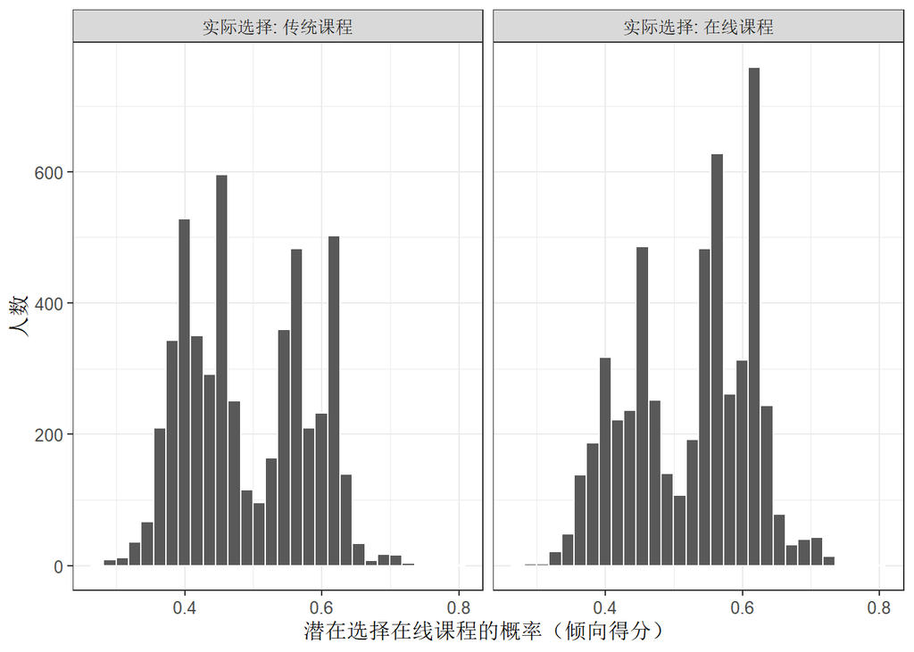

图4.1: 潜在选择在线课程的概率分布对比

### 4.4.3 倾向匹配分析

采用R包`MatchIt`中的一种全局性匹配算法**full**进行完全样本匹配(King et al. 2011; Guo and Fraser 2014, pg:190–194)。该最优化匹配算法（full）能够根据全部样本的倾向得分，利用全局性的距离最近匹配规则，尽量保留实验组样本（本研究中为选择在线课程的学生），并把处置条件不同（选择在线课程，或者选择传统课程）、但倾向得分相近的样本做完全配对。算法匹配的最终结果为：匹配样本总数为10331；因为是完全配对，选择在线课程的匹配样本数为5253，选择传统课程的匹配样本数为5078；未匹配而丢弃的样本数为0。

如果样本匹配较好，那么**处置组**和**控制组**将会在每一个协变量上都具有相同的倾向得分值。对匹配后的样本数据做分组均值差异的t检验分析，进一步表明配对样本协变量均值是无差异的，也即样本在协变量上是平衡的。而且匹配后的样本数据（总数为10331）在重要**协变量**平衡上的有了明显改善（见表4.5）。

表4.5: 倾向得分匹配后样本在协变量平衡上的改善情况

| 变量 | 均值差改善百分比% | QQ图均值差改善百分比% |
| --- | --- | --- |
| distance | 99.9% | 95% |
| score_diff | 53.3% | 15% |
| age_enroll | 9.8% | -224% |
| province_east | 66.5% | 44% |
| role_sci | 64.1% | 56% |
| nation_han | 83.1% | 88% |
| politic_CPM | 78.5% | 79% |
| habitat_rural | 98.5% | 93% |
| batch_cur | 41.8% | -199% |
| gender_female | 98.2% | 99% |

说明： Q-Q图差异对比指标此处仅使用均值指标。

### 4.4.4 学习成绩的多元回归分析

利用倾向得分匹配后的新数据，构建影响学生课程成绩（score）的多元虚拟变量回归模型，最终估计结果如下（见表4.6）：

表4.6: 学习效果的多元回归模型估计结果

| 变量 | 回归系数b | 标准误se | t统计量 | 概率p | 显著性 |
| --- | --- | --- | --- | --- | --- |
| (Intercept) | 72.8541 | 3.5019 | 20.8043 | 0.0000 | *** |
| treat | 1.5205 | 0.2851 | 5.3328 | 0.0000 | *** |
| score_diff | 0.0212 | 0.0041 | 5.2166 | 0.0000 | *** |
| age_enroll | -0.0921 | 0.1708 | -0.5395 | 0.5896 |  |
| province_east | 0.4218 | 0.3299 | 1.2784 | 0.2011 |  |
| role_sci | -1.7569 | 0.5729 | -3.0668 | 0.0022 | *** |
| nation_han | 0.0970 | 0.5300 | 0.1830 | 0.8548 |  |
| politic_CPM | 2.6511 | 0.3822 | 6.9357 | 0.0000 | *** |
| habitat_rural | 1.3510 | 0.2920 | 4.6272 | 0.0000 | *** |
| batch_cur | 0.3107 | 0.4324 | 0.7186 | 0.4724 |  |
| gender_female | 3.4179 | 0.2909 | 11.7502 | 0.0000 | *** |

说明： $\\ast\\ast\\ast$表示极显著；$\\ast\\ast$表示比较显著；$\\ast$表示显著

最终估计的样本回归函数为：

$$\begin{equation}
\begin{alignedat}{999}
&\widehat{score}=&&+72.85&&+1.52treat&&+0.02score_{diff}&&-0.09age_{enroll}\\
&\text{(t)}&&(20.8043)&&(5.3328)&&(5.2166)&&(-0.5395)\\&\text{(se)}&&(3.5019)&&(0.2851)&&(0.0041)&&(0.1708)\\&\text{(cont.)}&&+0.42province_{east}&&-1.76role_{sci}&&+0.10nation_{han}&&+2.65politic_{CPM}\\&\text{(t)}&&(1.2784)&&(-3.0668)&&(0.1830)&&(6.9357)\\&\text{(se)}&&(0.3299)&&(0.5729)&&(0.5300)&&(0.3822)\\&\text{(cont.)}&&+1.35habitat_{rural}&&+0.31batch_{cur}&&+3.42gender_{female}\\&\text{(t)}&&(4.6272)&&(0.7186)&&(11.7502)\\&\text{(se)}&&(0.2920)&&(0.4324)&&(0.2909)\\&\text{(fitness)}&& R^2=0.0274;&& \bar{R^2}=0.0264\\& && F^{\ast}=29.06;&& p=0.0000\\
\end{alignedat}
\end{equation}$$

以上回归结果表明：（1）作为最关心的重要变量，是否选择在线课程（处置条件treat）对课程成绩有显著正向影响。如果某个学生选择在线课程，则会比其选择传统课程高1.5205分。（2）高考分数与录取线的分差（socre-diff）对课程学习成绩有显著正向影响，其系数为0.0212。如果一个学生高考分数与录取线（本省一本）的分差35分，那么这一分差水平将会为其带来课程成绩0.7406分的提高。（3）是否为理科生（role_sci）表现出显著负向影响作用，意味着一个理科生相比于一个文科生，其课程成绩要相对少-1.7569分。（4）政治面貌为共产党员的学生（politic_CMP）成绩显著要高于其他情形（共青团员或群众），相比其他情形（共青团员或群众）其课程成绩要显著高出2.6511分。（5）来自农村的学生（habitat_rural），其课程成绩要显著好于来自城镇的学生，平均约高出1.351分。（6）女性学生（gender_female），其课程成绩要显著好于男性学生，平均约高出3.4179分。（7）学生入学年龄（age_roll）、是否是东部省区（province_east）、是否是汉族（nation_han）、是否为应届生（batch_cur）对课程成绩没有显著影响，这与大多数相关研究的结论基本一致。

### 4.4.5 计算处置效应

第一，利用以上回归结果，且给定**基准群体**为：选择传统课程、入学年龄为19岁、入学录取分差为36分、生源地为东部省份、理科生、汉族、共产党员、户籍为农村、应届、女生（也即：treat=0；age_enroll=19；score_diff=36；province_east=1；role_sci=1；nation_han=1；politic_CPM=1；habitat_rural=1；batch_cur=1；gender_female=1），我们可以分析几类典型群体的学习成绩与基准群体的差异（见表4.7）。结果表明，男生的在线课成绩会**潜在低于**其传统课程成绩；高考分数与录取线分差小的学生、来自城镇的学生、非东部生源学生，这三类群体在线课程成绩都会**潜在高于**其传统课程成绩。

表4.7: 几类典型群体的学习成绩（与基准组对比）

| 群组命名 | 群组特征 | 处置条件均值比较 传统课程 | 处置条件均值比较 在线课程 | 处置条件均值比较 均值差 |
| --- | --- | --- | --- | --- |
| 男性群体 | treat=1;gender_female=0 | 78.38 | 76.48 | -1.9024 |
| 高考分差低的群体 | treat=1;score_diff=5 | 78.37 | 79.23 | 0.8587 |
| 城镇群体 | treat=1;habitat_rural=0 | 78.37 | 78.53 | 0.1639 |
| 非东部生源群体 | treat=1;province_east=0 | 78.37 | 79.47 | 1.1038 |

表4.8: 处置效应ATE和ATT计算表

| 效应类型 | 处置条件均值mean 在线课程 | 处置条件均值mean 传统课程 | 效应值TE | 标准误se | 置信水平 2.5% | 置信水平 97.5% |
| --- | --- | --- | --- | --- | --- | --- |
| ATE | 73.83 | 74.65 | -0.4112 | 0.457 | 73.61 | 75.07 |
| ATT | 73.83 | 73.67 | 0.0806 | 6.851 | 58.04 | 89.99 |

说明： 采用bootstrap迭代法进行1000次模拟计算得到。

第二，**平均处置效应**（ATE）是“对课程选择行为做出**矫正后**的平均效应”。简言之，它能回答：**在线课程选择**存在的条件下，**全体学生**平均收益水平是多少？根据模型估计和预测结果（见表4.8），**平均处置效应**（ATE）为-0.4112，表明如果学生能够自由选择在线课程，那么全体学生的课程成绩能够平均降低了-0.4112分。

第三，**处置后的平均处置效应**（ATT）是“学生实际选择**在线课程**的平均效应”。 简言之，它能回答：实际选择在线课程的学生群体平均收益水平是多少？根据模型估计和预测结果（见表4.8），**处置后的平均处置效应**（ATT）为0.0806，表明如果学生实际选择在线课程，那么这些选择在线课程的学生，其课程成绩能够平均提高0.0806分。

总结起来，如果学生能够自由选择**在线课程**，那么在线课程学习能够提高其课程成绩（ATT为正数）；但是正因为学生有了这种自由选择，却带来了全体学生平均课程成绩的降低（ATE为负数）。再加上，如果可以自由选择在线课程情形下，学生的成绩差异变大（ATT的标准误se较大，预测的置信区间增大），因此可以认为：（1）提供同时选择**传统课程**和**在线课程**的自由性，则会**减低**学生学习成绩的稳定性（ATE效应）。（2）**在线课程**学习一方面可以成为某些学生群体（如能充分利用在线课程时空便利性等学生群体）的“成绩刷分器”——确实可以提高其课程成绩（ATT效应）；另一方面也成为某些学生群体（如高考录取分差小或/且男性学生群体）的“心理庇护所”——看似更自由学习形式背后可能潜藏更高的低成绩风险。

# 5 在线课程评价指标体系和问卷题项

根据前述文献综述，本研究初步设计了如下在线课程评价指标体系（见表5.1）:

表5.1: 在线课程评价指标体系设计

| 一级指标 | 二级指标 | 三级指标 |
| --- | --- | --- |
| 课程内容与设计 | 内容设计 | 课程设计合理，教学目标和重点明确，课程难易程度适当。 |
|  | 教学组织 | 您认为该课程教学组织形式得当，授课时长设置安排合理、课程小测验和课后作业布置适量。 |
|  | 内容获得感 | 授课内容精彩，您能掌握课程内容。 |
| 教师水平 | 专业能力 | 教师学识渊博，教学水平高。 |
|  | 讲授能力 | 教师讲课条理清楚、通俗易懂，讲课表现力强，很吸引人，您学习时能保持注意力。 |
|  | 授课方法 | 教师讲授内容具有启发性，能鼓励学生积极提问与讨论。 |
| 教学资源 | 教学资源的丰富性 | 该门课程文本资料、练习题、作业、视音频等教学资源充足，能满足学习需求。 |
|  | 教学资源的可得性 | 可以随时学习课程，课程资源方便下载，学习平台运行稳定。 |
|  | 教学资源的合理性 | 课程资源（如论坛、视频、阅读材料、测试材料）设计合理，课程资源更新及时。 |
| 学习过程 | 生生交互活动 | 课程的在线论坛、讨论交流对您学习课程很有帮助。 |
|  | 师生过程指导 | 学习时遇到问题容易获得帮助，教师能及时解答您提出的问题，在线答疑及时有效。 |
| 考核 | 评分方式 | 该课程的成绩构成和评分方式合理、公平。 |
|  | 考核内容 | 课程测验和考试题难度合适、数量设置合理、知识点覆盖全面，能帮助您检测学习效果。 |
| 学习支持 | 界面布局 | 课程平台界面设计清晰，美观，操作容易，使用方便。 |
|  | 视频质量 | 课程在线视频观看流畅、声音、画面清晰。 |
|  | 功能支持 | 学习平台的各项功能（如笔记、测试、互动、答疑等）设置完善。 |
| 总体评价 | 获得感 | 该门课程具有启发性，拓展了您的知识，对其他课程学习很有帮助，学习这门课程，您收获很大。 |
|  | 满意度 | 您对这门课程总体满意。 |

针对前述评价体系和项目实践思考，初步设计如下主要问卷题项：

(1). 该门课程具有启发性，拓展了您的知识，对其他课程学习很有帮助，学习这门课程，您收获很大。

(2). 您对这门课程总体满意。

(3). 您愿意向其他人推荐这门课程。

(4). 课程教师教学指导思想正确，无错误意识形态和观点。

(5). 教师讲课条理清楚、通俗易懂，很吸引人，您学习时能保持注意力。

(6). 教师能用多种方式对学生进行指导，老师指导对学习本课程有很大的帮助。

(7). 课程设计合理，教学目标、重点、难点明确，授课内容精彩。

(8). 该门课程文本资料、练习题、作业、视音频等教学资源充足。

(9). 课程设计和提供的学习资源能满足您的学习需求。

(10). 该课程教学组织形式得当，授课时长设置安排合理、课程小测验和课后作业布置适量。

(11). 相对于传统课程，在线学习该门课程增加了学习难度，更具有挑战性。

(12). 该课程的成绩构成和评价方式合理、公平，能帮助您检测学习效果。

(13). 课程在线视频观看流畅、声音、画面清晰，在线课程学习没有出现因网络或平台原因影响正常听课的情况。

(14). 学习平台的各项功能（如笔记、测试、互动、答疑等）设置完善。

(15). 课程资源更新及时。

(16). 课程平台界面设计清晰，美观，操作容易，使用方便。

(17). 教师鼓励学生参与提问与讨论，能积极参与课程讨论，引导学生积极思考

(18). 学习时遇到问题容易获得帮助，教师能及时解答您提出的问题，在线答疑及时有效。

(19). 在线论坛、讨论交流对学习课程很有帮助。

(20). 您愿意积极参与讨论与交流。

(21). 您愿意选择在线课程学习形式，下学期您是否将继续选择在线课程学习。

(22). 与传统课程相比，您选择在线学习课程的原因。

# 6 研究结论和特色之处

## 6.1 主要研究结论

本项目主要分析了学生课程形式选择、学习投入与学习效果的关系等议题，通过收集了四个年级（2013-2016级）共19452名学生在11个连续学期（2013秋学期-2018春学期）上的通识课程学习相关数据，进行了相关实证分析。本研究实证分析部分重点比较了学生在传统课程和在线课程上的学习行为和学习效果差异。主要研究结论包括：

(1). 为了完成通识课程模块学分，大部分学生在传统通识课程和在线通识课程之间做出了理性选择和平衡。大部分学生的通识课学分获得任务主要在前两年就会完成,学生在各个观察年的累计获得通识课程总学分基本服从正态分布。大部分学生在大一阶段获得基本的传统课学分，随后的学业阶段多是课程的兴趣选择和学分的择机补足。大部分学生都会大二学年及以前选择并获得相应的在线课程学分，后续阶段基本就不再通过在线课程平台获得通识课程学分。

(2). 学生不会因为“新奇”心理而参加在线课程平台（无论是智慧树平台还是尔雅平台），更多只是为了完成通识课学分要求，因而学生的学习行为表现出典型的“理性人”特点。即便是同时拥有两个在线课程平台的选择自由，学生的选课决策和学习行为更多地是受到学分政策、平台依赖性等因素的决定。

(4). 对于在线课程学习形式的选择倾向分析中，发现高考分数与一本录取线分差越大、入学年龄越大、理科生、政治面貌为党员、来自农村地区、女生，越**不倾向**于选择在线课程。而且无论是实际选择在线课程的学生群体，还是实际选择传统课程的学生群体，他们的潜在选择倾向都呈现明显的“双峰分布”，意味着在线课程和传统课程学习形式在学生的选择决策中，潜在地具有较强的替代性关系。

(5). 对于课程学习效果的影响分析中，分析发现是否选择在线课程对课程成绩有显著正向影响。如果某个学生选择在线课程，则会比其选择传统课程高1.5205分。高考分数与录取线的分差（socre-diff）对课程学习成绩有显著正向影响。如果一个学生高考分数与录取线（本省一本）的分差35分，那么这一分差水平将会为其带来课程成绩0.7406分的提高。

(6). 倾向匹配方法的处置效应分析发现，男生的在线课成绩会潜在低于其传统课程成绩；高考分数与录取线分差小的学生、来自城镇的学生、非东部生源学生，这三类群体在线课程成绩都会潜在高于其传统课程成绩。如果学生能够自由选择在线课程，那么在线课程学习能够提高其课程成绩（ATT为正数）；但是正因为学生有了这种自由选择，却带来了全体学生平均课程成绩的降低（ATE为负数）。提供同时选择传统课程和在线课程的自由性，则会减低学生学习成绩的稳定性（ATE效应）。在线课程学习一方面可以成为某些学生群体（如能充分利用在线课程时空便利性等学生群体）的“成绩刷分器”——确实可以提高其课程成绩（ATT效应）；另一方面也成为某些学生群体（如高考录取分差小或/且男性学生群体）的“心理庇护所”——看似更自由学习形式背后可能潜藏更高的低成绩风险。

## 6.2 特色之处

第一，本研究利用大数据技术进行学习行为的数据挖掘、建模和实证分析，充分发挥教学实践中海量“沉默数据”、“孤岛数据”的社会价值，通过团队协作，有效地实现了“数据资源与分析能力”的创新整合。在研究工作范式上，对于教学改革研究实践具有一定启发意义。

第二，采用倾向得分分析法来论述学习行为与学习效果的**因果关系**，避免简单回归分析法中普遍存在的选择偏误和内生性问题，有利于得到更为客观的结论。这一方法框架还可以进一步加以扩展应用，并作出更全面的分析，潜在理论价值较大。

第三，本研究的主要结论中，重点指出在线课程可能会潜在带来学生整体学习效果的弱化。这一结论对于在线课程平台提供商市场开发、高校在线课程学分认定及相关政策制订等，具有重要的应用参考价值。

# 参考文献

Adamopoulos, Panagiotis. 2013. “What Makes a Great Mooc? An Interdisciplinary Analysis of Student Retention in Online Courses.” In *34th International Conference on Information Systems: ICIS 2013*. Association for Information Systems.

Akyol, Zehra, and D Randy Garrison. 2011. “Understanding Cognitive Presence in an Online and Blended Community of Inquiry: Assessing Outcomes and Processes for Deep Approaches to Learning.” *British Journal of Educational Technology* 42 (2): 233–50.

Alpert, William T, Kenneth A Couch, and Oskar R Harmon. 2016. “A Randomized Assessment of Online Learning.” *American Economic Review* 106 (5): 378–82.

Amador, José A, and Helen Mederer. 2013. “Migrating Successful Student Engagement Strategies Online: Opportunities and Challenges Using Jigsaw Groups and Problem-Based Learning.”

Appleton, James J, Sandra L Christenson, and Michael J Furlong. 2008. “Student Engagement with School: Critical Conceptual and Methodological Issues of the Construct.” *Psychology in the Schools* 45 (5): 369–86.

Barab, Sasha A. 2003. “An Introduction to the Special Issue: Designing for Virtual Communities in the Service of Learning.” *The Information Society* 19 (3): 197–201.

Bhattacherjee, Anol. 2001. “Understanding Information Systems Continuance: An Expectation-Confirmation Model.” *MIS Quarterly*, 351–70.

Bhattacherjee, Anol, Johan Perols, and Clive Sanford. 2008. “Information Technology Continuance: A Theoretic Extension and Empirical Test.” *Journal of Computer Information Systems* 49 (1): 17–26.

Brown, Ann L, and Joseph C Campione. 1994. *Guided Discovery in a Community of Learners.* The MIT Press.

Coates, Dennis, Brad R Humphreys, John Kane, and Michelle A Vachris. 2004. “‘No Significant Distance’ Between Face-to-Face and Online Instruction: Evidence from Principles of Economics.” *Economics of Education Review* 23 (5): 533–46.

Davis, James L. 1996. “Computer-Assisted Distance Learning, Part Ii: Examination Performance of Students on and Off Campus.” *Journal of Engineering Education* 85 (1): 77–82.

Deschacht, Nick, and Katie Goeman. 2015. “The Effect of Blended Learning on Course Persistence and Performance of Adult Learners: A Difference-in-Differences Analysis.” *Computers & Education* 87: 83–89.

Dixson, Marcia D. 2010. “Creating Effective Student Engagement in Online Courses: What Do Students Find Engaging?” *Journal of the Scholarship of Teaching and Learning*, 1–13.

Figlio, David, Mark Rush, and Lu Yin. 2013. “Is It Live or Is It Internet? Experimental Estimates of the Effects of Online Instruction on Student Learning.” *Journal of Labor Economics* 31 (4): 763–84.

Fillion, Gérard, Moez Limayem, Thérèse Laferrière, and Robert Mantha. 2007. “INTEGRATING Ict into Higher Education: A Study of Onsite Vs Online Students’PERCEPTIONS.” *Academy of Educational Leadership Journal* 11 (2).

Fredricks, Jennifer A, Phyllis C Blumenfeld, and Alison H Paris. 2004. “School Engagement: Potential of the Concept, State of the Evidence.” *Review of Educational Research* 74 (1): 59–109.

Garrison, D Randy, and J Ben Arbaugh. 2007. “Researching the Community of Inquiry Framework: Review, Issues, and Future Directions.” *The Internet and Higher Education* 10 (3): 157–72.

Gefen, David. 2003. “TAM or Just Plain Habit: A Look at Experienced Online Shoppers.” *Journal of Organizational and End User Computing (JOEUC)* 15 (3): 1–13.

Guo, Shenyang, and Mark W Fraser. 2014. *Propensity Score Analysis*. Sage.

Hagel, Pauline, and Robin N Shaw. 2010. “How Important Is Study Mode in Student University Choice?” *Higher Education Quarterly* 64 (2): 161–82.

Harrell, Ivan L, and Beverly L Bower. 2011. “Student Characteristics That Predict Persistence in Community College Online Courses.” *American Journal of Distance Education* 25 (3): 178–91.

Henrie, Curtis R, Lisa R Halverson, and Charles R Graham. 2015. “Measuring Student Engagement in Technology-Mediated Learning: A Review.” *Computers & Education* 90: 36–53.

Hrastinski, Stefan. 2009. “A Theory of Online Learning as Online Participation.” *Computers & Education* 52 (1): 78–82.

Huntington-Klein, Nick, James Cowan, and Dan Goldhaber. 2017. “Selection into Online Community College Courses and Their Effects on Persistence.” *Research in Higher Education* 58 (3): 244–69.

Imai, Kosuke, Gary King, and Elizabeth Stuart. 2008. “Misunderstandings Among Experimentalists and Observationalists About Causal Inference.” *Journal of the Royal Statistical Society, Series A* 171, part 2: 481502.

Joyce, Ted, Sean Crockett, David A Jaeger, Onur Altindag, and Stephen D O’Connell. 2015. “Does Classroom Time Matter?” *Economics of Education Review* 46: 64–77.

Kester, Liesbeth, Peter Van Rosmalen, Peter Sloep, Francis Brouns, Malik Koné, and Rob Koper. 2007. “Matchmaking in Learning Networks: Bringing Learners Together for Knowledge Sharing.” *Interactive Learning Environments* 15 (2): 117–26.

Kim, Sung S, and Naresh K Malhotra. 2005. “A Longitudinal Model of Continued Is Use: An Integrative View of Four Mechanisms Underlying Postadoption Phenomena.” *Management Science* 51 (5): 741–55.

King, Gary, Daniel Ho, Elizabeth A Stuart, and Kosuke Imai. 2011. “MatchIt: Nonparametric Preprocessing for Parametric Causal Inference.” *Journal of Statistical Software* 42 (8): 1–28.

Kizilcec, René F, Chris Piech, and Emily Schneider. 2013. “Deconstructing Disengagement: Analyzing Learner Subpopulations in Massive Open Online Courses.” In *Proceedings of the Third International Conference on Learning Analytics and Knowledge*, 170–79. ACM.

Krieg, John M, and Steven E Henson. 2016. “The Educational Impact of Online Learning: How Do University Students Perform in Subsequent Courses?” *Education Finance and Policy* 11 (4): 426–48.

Kuh, George D. 2003. “What We’re Learning About Student Engagement from Nsse: Benchmarks for Effective Educational Practices.” *Change: The Magazine of Higher Learning* 35 (2): 24–32.

Lee, Cheng-Yuan. 2015. “Changes in Self-Efficacy and Task Value in Online Learning.” *Distance Education* 36 (1): 59–79.

Leite, Walter L, Marilla Svinicki, and Yuying Shi. 2010. “Attempted Validation of the Scores of the Vark: Learning Styles Inventory with Multitrait–Multimethod Confirmatory Factor Analysis Models.” *Educational and Psychological Measurement* 70 (2): 323–39.

Maltby, John R, and Jan Whittle. 2000. “Learning Programming Online: Student Perceptions and Performance.” In *Proceedings of the Ascilite 2000 Conference*. Citeseer.

McNaught, Carmel, Paul Lam, and Kin Fai Cheng. 2012. “Investigating Relationships Between Features of Learning Designs and Student Learning Outcomes.” *Educational Technology Research and Development* 60 (2): 271–86.

Milligan, Colin, Allison Littlejohn, and Anoush Margaryan. 2013. “Patterns of Engagement in Connectivist Moocs.” *MERLOT Journal of Online Learning and Teaching* 9 (2).

Newig, Jens, Dirk Günther, and Claudia Pahl-Wostl. 2010. “Synapses in the Network: Learning in Governance Networks in the Context of Environmental Management.” *Ecology and Society* 15 (4).

Peck, Jennifer J, and others. 2012. “Keeping It Social: Engaging Students Online and in Class.”

Petty, Teresa, and Abiola A Farinde. 2013. “Investigating Student Engagement in an Online Mathematics Course Through Windows into Teaching and Learning.” *Journal of Online Learning & Teaching* 9 (2).

Reeve, Johnmarshall, and Ching-Mei Tseng. 2011. “Agency as a Fourth Aspect of Students’ Engagement During Learning Activities.” *Contemporary Educational Psychology* 36 (4): 257–67.

Robinson, Chin Choo, and Hallett Hullinger. 2008. “New Benchmarks in Higher Education: Student Engagement in Online Learning.” *Journal of Education for Business* 84 (2): 101–9.

Roblyer, Mi D. 1999. “Is Choice Important in Distance Learning? A Study of Student Motives for Taking Internet-Based Courses at the High School and Community College Levels.” *Journal of Research on Computing in Education* 32 (1): 157–71.

Rosenbaum, Paul R. 2010. *Design of Observational Studies*. Vol. 10. Springer.

Rosenbaum, Paul R, and others. 1987. “The Role of a Second Control Group in an Observational Study.” *Statistical Science* 2 (3): 292–306.

Schaufeli, Wilmar B, Isabel M Martinez, Alexandra Marques Pinto, Marisa Salanova, and Arnold B Bakker. 2002. “Burnout and Engagement in University Students: A Cross-National Study.” *Journal of Cross-Cultural Psychology* 33 (5): 464–81.

Shea, Peter, and Temi Bidjerano. 2012. “Learning Presence as a Moderator in the Community of Inquiry Model.” *Computers & Education* 59 (2): 316–26.

Xu, Di, and Shanna Smith Jaggars. 2013. “The Impact of Online Learning on Students’ Course Outcomes: Evidence from a Large Community and Technical College System.” *Economics of Education Review* 37: 46–57.

刘人境, 张谦, and 闵文文. 2013. “知识心理所有权与隐性知识共享关系研究.” *科技进步与对策* 30 (9): 134–37.

吴南中. 2016. “在线学习培育的顶层设计与推进机制研究 [J].” *电化教育研究* 37 (1): 45–50.

姜蔺, 韩锡斌, and 程建钢. 2013. “MOOCs 学习者特征及学习效果分析研究.” *中国电化教育* 11: 54–59.

孔丽丽, 马志强, 易玉何, 杨昊, and others. 2017. “在线学习行为影响因素模型研究——基于行为科学理论的评述.” *北京广播电视大学学报*, no. 2017 年 05: 46–53.

季志. 2013. “大学生网络学习行为模型与实证研究.” *中国远程教育* 5: 62.

宗阳, 孙洪涛, 张亨国, 郑勤华, and 陈丽. 2016. “MOOCs 学习行为与学习效果的逻辑回归分析.” *中国远程教育*, no. 5: 14–22.

张哲, 王以宁, 陈晓慧, and 高焱. 2016. “MOOC 持续学习意向影响因素的实证研究——基于改进的期望确认模型.” *电化教育研究* 37 (5): 30–36.

张晓蕾, 黄振中, and 李曼丽. 2017. “在线学习者 ‘交互学习’ 体验及其对学习效果影响的实证研究.” *清华大学教育研究*, no. 2: 117–24.

张琪. 2015. “E-Learning 环境中大学生自我效能感与深度学习的相关性研究.” *电化教育研究* 36 (4): 55–61.

张秀芹, and others. 2017. “在线课程学分认定现状, 问题与对策——基于 61 所高校的调研报告.” *中国大学教学*, no. 2017 年 01: 79–83.

方旭, and others. 2015. “MOOC 学习行为影响因素研究.” *开放教育研究*, no. 2015 年 03: 46–54.

易玉何, 马志强, 孔丽丽, and others. 2018. “高校慕课持续使用行为影响因素建模研究——基于持续使用行为理论的视角.” *中国教育信息化 高教职教*, no. 2018 年 02: 17–21.

曹良亮. 2014. “在线学习中学习路径分析及学习行为特点研究.” *中国远程教育*, no. 4: 25–30.

杨根福. 2016. “MOOC 用户持续使用行为影响因素研究.” *开放教育研究* 22 (1): 100–111.

梁林梅. 2015. “MOOCs 学习者: 分类, 特征与坚持性.” *比较教育研究* 1: 28–34.

江波, 高明, 陈志翰, and 王小霞. 2018. “基于行为序列的学习过程分析与学习效果预测.” *现代远程教育研究*, no. 2: 103–12.

洪岩, 唐卉, and 梁林梅. 2013. “美国高等网络教育发展的新态势——斯隆联盟 2010 和 2011 年度调查报告综述.” *中国远程教育* 1.

熊才平, 何向阳, and 吴瑞华. 2012. “论信息技术对教育发展的革命性影响.” *教育研究* 6: 22–29.

王卫, 史锐涵, and 李晓娜. 2017. “基于心流体验的在线学习持续意愿影响因素研究.” *中国远程教育*, no. 5: 17–23.

王涛涛, and 毛晨蕾. 2018. “基于学习分析的在线课程学习效果评价研究.” *中国成人教育*, no. 17: 27.

王钱永, and 毛海波. 2016. “基于 Utaut 模型的 Mooc 学习行为因素分析.” *电化教育研究* 37 (6): 43–48.

谭光兴, 徐峰, and 屈文建. 2012. “高校学生网络教学行为意向影响因素与模型.” *电化教育研究* 1: 47–53.

赵宏, 张亨国, 郑勤华, and 陈丽. 2017. “中国 Moocs 学习评价调查研究.” *中国电化教育* 9: 53–61.

陈渝, and 尹辉. 2013. “网络教育培训用户采纳意愿实证研究.” PhD thesis.

顾振华, and others. 2018. “混合型考核机制对大学生成绩的影响——基于经济学课程的实证分析.” *高等财经教育研究*, no. 2018 年 01: 11–16.

马志强, 苏珊, 张彤彤, and others. 2017. “基于学习投入理论的网络学习行为模型研究——以 ‘网络教学平台设计与开发’ 课程为例.” *现代教育技术*, no. 2017 年 01: 74–80.

高洁, and others. 2016. “在线学业情绪对学习投入的影响——社会认知理论的视角.” *开放教育研究*, no. 2016 年 02: 89–95.